# Projekt BI 2025/26 - grupa 2

## 1 Autorzy

Maria Zimmer (127910) i Tymoteusz Pomarzyński (127846)

## 2 Wprowadzenie

- zwięzły opis projektu dotyczący wyboru danych oraz estimatorów Celem projektu jest porównanie estymatorów na podstawie danych dotyczących gospodarstw domowych. Jako zmienną celu wybrano e1 - “Obecnie zatrudniony na podstawie umowy o pracę” a jako zmienne pomocnicze wykorzystano: wiek_4k (“Wiek respondenta (w przedziałach) - warstwy użyte w ważeniu”), miejsce_4k (“Miejsce zamieszkania respondenta”), g2_3 (“Podniósł umiejętności w ciągu ost. 5 lat”), k24 (“Gotowość do częstych wyjazdów”) oraz w9_1 (“Język obcy 1”). W ramach projektu porównano 4 estymatory: naiwny, estymator IPW oparty na odwrotnym ważeniu prawdopodobieństwem, gdzie model selekcji estymowany jest metodą największej wiarygodności, estymator masowej imputacji oparty na uogólnionym modelu liniowym oraz estymator masowej imputacji oparty na metodzie najbliższych sąsiadów.

## 3 Symulacja

### 3.1 Założenia

1. ustalono wielkość próby losowej na $n_a=1000$ i próby nielosowej na $n_b=500$,
2. próba nielosowa została wygenerowana za pomocą modelu logitowego przez nadanie każdej obserwacji prawdopodobieństwa wyboru zależnego od zmiennej g2_3 odpowiadającej za podnoszenie umiejętności przez respondentów
   $$logit(pA)=−2+1.54⋅umiej$$
3. zmienną celu jest e1 - “Obecnie zatrudniony na podstawie umowy o pracę”
4. Próbę losową wygenerowano na podstawie losowania prostego

### 3.2 Ocena estymatorów

Dla każdego estymatora obliczono średnią wartość estymatora z replikacji, obciążenie, wariancję, MSE i RMSE. Obciążenie informuje, czy dany estymator systematycznie zawyża lub zaniża wartość prawdziwego parametru. Wariancja pokazuje zmienność wyników, a MSE i RMSE służą do ogólnej oceny estymatorów.

```r
#estymator theta_srednia Bias          Variance      MSE           RMSE
#IPW_MLE        0.5210916       0.0009547413    0.0006104515    0.000611363 0.02472576
#MI_GLM       0.5202974     0.0001605887    0.0005721982    0.000572224 0.02392120
#MI_NN      0.5439784       0.0238415628    0.0007594624    0.001327883 0.03644012
#naiwny       0.5969360     0.0767991628    0.0004194599    0.006317571 0.07948315
```

Najlepszy okazał się estymator masowej imputacji glm jednak nieznacznie gorszy od niego okazał się estymator ipw. Estymator naiwny znacznie przeszacowywał odsetek osób zatrudnionych na umowę o pracę, co przyczyniło nieporządanie, relatywnie wysokich miar MSE i RMSE. Estmator masowej imputacji wykorzystujący metodę najbliższych sąsiadów poprawia wyniki lepiej w stosunku do naiwnego jednak nadal nie tak dobrze jak ten wykonywany metodą glm czy estymator ipw, a ponadto charakteryzuje się najwyższą wariancją co wpływa niekorzystnie.

### 3.3 Kod do symulacji

```r
#wczytanie bibliotek
library(readxl)
library(tidyr)
library(haven)
library(nonprobsvy)
library(dplyr)
library(writexl)
library(forcats)
library(boot)
library(survey)
library(purrr)
library(ggplot2)

#wczytanie danych i ich przegląd
dane_bkl <- read_sav("Poczona_baza_danych_z_badania_ludnoci_z_lat_20172019_i_2021.sav")
attr(dane_bkl$e1, "labels")
```

```
brak danych         NDT         nie         tak
         -3          -1           0           1
```

```r
table(as_factor(dane_bkl$e1), useNA = "ifany")
```

```
brak danych         NDT         nie         tak
          0           0        4830        4288
```

```r
dane_bkl$Y <- ifelse(dane_bkl$e1 == 1, 1,
                         ifelse(dane_bkl$e1 == 0, 0, NA))
table(dane_bkl$Y, useNA = "ifany")
```

```
   0    1
4830 4288
```

```r
prop.table(table(dane_bkl$Y)) * 100
```

```
       0        1
52.97214 47.02786
```

```r
table(dane_bkl$rok, dane_bkl$e1, useNA = "ifany")
```

```
          0    1
  2017 2152 1904
  2019 1345 1188
  2021  853  722
  2022  480  474
```

```r
prop.table(table(dane_bkl$rok, dane_bkl$e1), margin = 1) * 100
```

```
              0        1
  2017 53.05720 46.94280
  2019 53.09909 46.90091
  2021 54.15873 45.84127
  2022 50.31447 49.68553
```

```r
#agregacja kategorii zmiennych
dane_bkl$umiej <- case_when(
  as_factor(dane_bkl$g2_3) %in% c("zdecydowanie nie", "raczej nie") ~ 0,
  as_factor(dane_bkl$g2_3) %in% c("raczej tak", "zdecydowanie tak") ~ 1,
  as_factor(dane_bkl$g2_3) %in% c("trudno powiedzieć", "odmowa odpowiedzi", "brak danych", "NDT") ~ NA_real_,
  TRUE ~ NA_real_
)
dane_bkl <- dane_bkl %>%
  filter(!is.na(umiej))
dane_bkl$jez <- case_when(
  as_factor(dane_bkl$w9_1) %in% c("inny język", "łacina", "czeski", "holenderski, niderlandzki", "ukraiński", "białoruski", "grecki", "szwedzki", "norweski", "japoński", "romski", "chorwacki", "słowacki") ~ "inny",
  as_factor(dane_bkl$w9_1) %in% c("francuski", "hiszpański", "włoski") ~ "romański",
  as_factor(dane_bkl$w9_1) == "niemiecki" ~ "niemiecki",
  as_factor(dane_bkl$w9_1) == "rosyjski" ~ "rosyjski",
    as_factor(dane_bkl$w9_1) == "angielski" ~ "angielski",
  as_factor(dane_bkl$w9_1) %in% c("brak danych", "NDT") ~ NA_character_,
  TRUE ~ NA_character_
)
dane_bkl$jez <- factor(dane_bkl$jez, levels = c("inny", "romański", "niemiecki", "rosyjski", "angielski"))

#sprawdzenie powiązania zmiennych x z y
vars <- c("wiek_4k", "miejsce_4k", "umiej", "k24", "jez")
wyniki <- data.frame()
for (v in vars) {
  x <- dane_bkl[[v]]
  if (inherits(x, "haven_labelled")) {
    x <- as_factor(zap_missing(x))
  } else {
    x <- factor(x)
  }
  tmp <- data.frame(
    x = x,
    Y = dane_bkl$Y
  )
  tmp <- na.omit(tmp)
  tmp$x <- droplevels(tmp$x)
  tmp$Y <- droplevels(factor(tmp$Y))
  tab <- table(tmp$x, tmp$Y)
  test <- suppressWarnings(chisq.test(tab, correct = FALSE))
  chi2 <- as.numeric(test$statistic)
  n <- sum(tab)
  V <- sqrt(chi2 / (n * (min(dim(tab)) - 1)))
  wyniki <- rbind(wyniki, data.frame(
    zmienna = v,
    V_Cramera = round(V, 3),
    p_value = signif(test$p.value, 4),
    kategorie = nrow(tab),
    n = n
  ))
}
wyniki
```

| zmienna | V_Cramera | p_value | kategorie | n |
| --- | --- | --- | --- | --- |
| wiek_4k | 0.297 | 0 | 4 | 8772 |
| miejsce_4k | 0.107 | 0 | 4 | 8761 |
| umiej | 0.375 | 0 | 2 | 8772 |
| k24 | 0.162 | 0 | 5 | 8726 |
| jez | 0.183 | 0 | 5 | 6464 |

```r
# ograniczenie zbioru danych tylko do potrzebnych zapisując do obiektu dane
dane <- dane_bkl %>%
  select(e1, miejsce_4k, wiek_4k, umiej, k24, jez) %>%
  mutate(
    e1 = as_factor(e1),
    e1 = case_when(
      e1 == "tak" ~ 1,
      e1 == "nie" ~ 0,
      TRUE ~ NA_real_
    ),
    miejsce_4k = as_factor(miejsce_4k),
    miejsce_4k = factor(miejsce_4k),
    wiek_4k = as_factor(wiek_4k),
    wiek_4k = factor(wiek_4k),
    umiej = as.numeric(umiej),
    k24 = as_factor(k24),
    k24 = factor(k24),
    jez = factor(
      jez,
      levels = c("inny", "romański", "niemiecki", "rosyjski", "angielski")
    )
  ) %>%
  filter(
    !is.na(e1),
    !is.na(miejsce_4k),
    !is.na(wiek_4k),
    !is.na(umiej),
    !is.na(k24),
    !is.na(jez)
  ) %>%
  mutate(
    across(where(is.factor), fct_drop)
  )

#przegląd danych do losowania nielosowego
prop.table(table(dane$wiek_4k, dane$e1), margin = 1) * 100
```

```
               0        1
  18-29 52.82486 47.17514
  30-39 29.87013 70.12987
  40-49 33.25123 66.74877
  50-69 64.09597 35.90403
```

```r
prop.table(table(dane$miejsce_4k, dane$e1), margin = 1) * 100
```

```
                                0        1
  wieś                   52.54973 47.45027
  miasto do 19 999       45.65388 54.34612
  miasto 20 000 - 99 999 47.74934 52.25066
  miasto 100 000 +       40.52548 59.47452
```

```r
prop.table(table(dane$umiej, dane$e1), margin = 1) * 100
```

```
           0        1
  0 71.57162 28.42838
  1 34.88147 65.11853
```

```r
prop.table(table(dane$k24, dane$e1), margin = 1) * 100
```

```
                       0        1
  niski         59.78742 40.21258
  podstawowy    49.33974 50.66026
  średni        41.88235 58.11765
  wysoki        47.73414 52.26586
  bardzo wysoki 46.44412 53.55588
```

```r
prop.table(table(dane$jez, dane$e1), margin = 1) * 100
```

```
                   0        1
  inny      59.32203 40.67797
  romański  50.40650 49.59350
  niemiecki 47.36181 52.63819
  rosyjski  60.56891 39.43109
  angielski 40.33392 59.66608
```

```r
tab_umiej <- prop.table(table(umiej = dane$umiej, e1 = dane$e1),margin = 1)
p_tak_umiej_tak <- tab_umiej["1", "1"]
p_tak_umiej_nie <- tab_umiej["0", "1"]
odds_umiej_tak <- p_tak_umiej_tak / (1 - p_tak_umiej_tak)
odds_umiej_nie <- p_tak_umiej_nie / (1 - p_tak_umiej_nie)
beta_umiej <- log(odds_umiej_tak / odds_umiej_nie)

#funkcja do przeprowadzania symulacji
symulacja <-
  function (a){
  set.seed(200+a)
  dane <- dane %>%
    mutate(
      logit_p_A = -2 + beta_umiej * umiej,
      p_A = plogis(logit_p_A)
    )
  #próba nielosowa S_A
  S_A <- dane %>%
    slice_sample(
      n = 500,
      replace = FALSE,
      weight_by = p_A
    )
  #próba losowa S_B
  S_B <- dane %>%
    slice_sample(
      n = 1000,
      replace = FALSE
    ) %>%
    mutate(
      w_B = nrow(dane) / 1000
    )
  #zbiór próba losowa
  S_B_svy <- svydesign(
    ids = ~1,
    weights = ~w_B,
    data = S_B
  )
  #estymator naiwny
  est_naiwny <- mean(S_A$e1)

  #estymator ipw
  est1_mean <- tryCatch({
    est1 <- nonprob(
      data = S_A,
      selection = ~ miejsce_4k + wiek_4k + umiej + k24 + jez,
      target = ~ e1,
      svydesign = S_B_svy,
      method_selection = "logit"
    )
    as.numeric(extract(est1)$mean[1])
  }, error = function(e) NA_real_)

  #estymator mi glm
  est2_mean <- tryCatch({
    est2 <- nonprob(
      data = S_A,
      outcome = e1 ~ miejsce_4k + wiek_4k + umiej + k24 + jez,
      svydesign = S_B_svy,
      method_outcome = "glm",
      family_outcome = "binomial"
    )
    as.numeric(extract(est2)$mean[1])
  }, error = function(e) NA_real_)

    #estymator mi nn
  est3_mean <- tryCatch({
    est3 <- nonprob(
      data = S_A,
      outcome = e1 ~ miejsce_4k + wiek_4k + umiej + k24 + jez,
      svydesign = S_B_svy,
      method_outcome = "nn",
      control_outcome = control_out(k = 5)
    )
    as.numeric(extract(est3)$mean[1])
  }, error = function(e) NA_real_)

  tibble(
    rep = a,
    naiwny = est_naiwny,
    IPW_MLE = est1_mean,
    MI_GLM = est2_mean,
    MI_NN = est3_mean
  )
  }
#porównaie prób S_A i S_B ze zbiorem bkl
#prop.table(table(dane$e1)) * 100
#prop.table(table(S_B$e1)) * 100
#prop.table(table(S_A$e1)) * 100

#symulacja dla 250 wywołań
wyniki_symulacji <- map_dfr(1:250, symulacja)

theta <- mean(dane$e1, na.rm = TRUE)
ocena_estymatorow <- wyniki_symulacji %>%
  pivot_longer(
    cols = c(naiwny, IPW_MLE, MI_GLM, MI_NN),
    names_to = "estymator",
    values_to = "theta_hat"
  ) %>%
  group_by(estymator) %>%
  summarise(
    B_udane = sum(!is.na(theta_hat)),
    theta_srednia = mean(theta_hat, na.rm = TRUE),
    Bias = theta_srednia - theta,
    Variance = mean((theta_hat - theta_srednia)^2, na.rm = TRUE),
    MSE = Bias^2 + Variance,
    RMSE = sqrt(MSE),
    .groups = "drop"
  )
```

## 4 Wyniki symulacji

```r
ocena_estymatorow
```

| estymator | B_udane | theta_srednia | Bias | Variance | MSE | RMSE |
| --- | --- | --- | --- | --- | --- | --- |
| IPW_MLE | 250 | 0.5210916 | 0.0009547 | 0.0006105 | 0.0006114 | 0.0247258 |
| MI_GLM | 249 | 0.5202974 | 0.0001606 | 0.0005722 | 0.0005722 | 0.0239212 |
| MI_NN | 250 | 0.5439784 | 0.0238416 | 0.0007595 | 0.0013279 | 0.0364401 |
| naiwny | 250 | 0.5969360 | 0.0767992 | 0.0004195 | 0.0063176 | 0.0794832 |

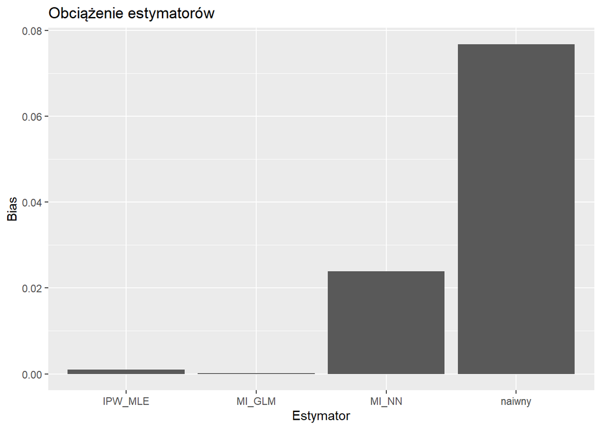

```r
ggplot(ocena_estymatorow, aes(x = estymator, y = Bias)) +
  geom_col() +
  labs(
    title = "Obciążenie estymatorów",
    x = "Estymator",
    y = "Bias"
  )
```

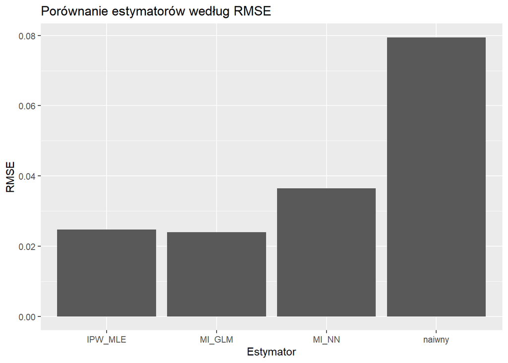

```r
ggplot(ocena_estymatorow, aes(x = estymator, y = RMSE)) +
  geom_col() +
  labs(
    title = "Porównanie estymatorów według RMSE",
    x = "Estymator",
    y = "RMSE"
  )
```

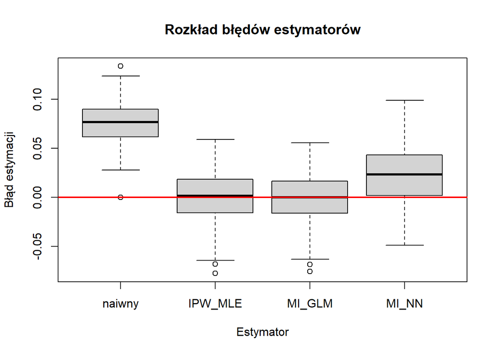

```r
bledy_estymatorow <- wyniki_symulacji %>%
  select(naiwny, IPW_MLE, MI_GLM, MI_NN) %>%
  mutate(
    across(everything(), ~ .x - theta)
  ) %>%
  as.data.frame()
boxplot(
  bledy_estymatorow,
  main = "Rozkład błędów estymatorów",
  xlab = "Estymator",
  ylab = "Błąd estymacji"
)

abline(h = 0, col = "red", lwd = 2)
```

Najlepiej wypadł estymator MI_GLM, bo ma najniższe MSE = 0.000572 i RMSE = 0.02392 a przede wszystkim najlepiej szacuje wartość odsetka osób zatrudnionych na umowę o pracę (Bias praktycznie zerowy ok. 0,00016), nieznacznie gorszy był estymator IPW_MLE, też ma bardzo małe obciążenie i RMSE. Te dwa estymatory dają bardzo podobne wyniki. MI_NN zawyża wynik, bo Bias wynosi ok. 0.024. Estymator MI-NN poprawiał wynik względem estymatora naiwnego, ale był mniej skuteczny niż MI-GLM i IPW-MLE. Może to wynikać z tego, że metoda najbliższych sąsiadów jest bardziej wrażliwa na strukturę danych. Estymator naiwny jest zdecydowanie najgorszy, bo mocno zawyża odsetek zatrudnionych na umowę o pracę (Bias ok. 0.077) i ma znacznie wyższe od pozostałych wartości MSE i RMSE.

## 5 Podsumowanie

W przeprowadzonej symulacji próba nielosowa miała zawyżony odsetek osób zatrudnionych na podstawie umowy o pracę, związany z tym, że więcej ludzi podnoszących swoje umiejętności znajdywała się w badanej próbie. Wkazuje na to estymator naiwny, który jest wyraźnie wyższy od rzeczywistej wartości parametru w populacji. Estymatory korygujące poprawiły wynik, ponieważ wykorzystywały zmienne pomocnicze. MI-GLM osiągnął najlepszy wynik, ponieważ jednocześnie zachował bardzo małe obciążenie i umiarkowaną zmienność. Oznacza to, że nie tylko przeciętnie trafnie odtwarzał wartość populacyjną, ale także był stabilny w kolejnych replikacjach symulacji. Estymator IPW-MLE również wypadł bardzo dobrze i dawał wyniki zbliżone do MI-GLM.